This Homework belongs to Naba kishor Sahoo (nabsahoo@iu.edu)

# Homework 3 - Machine Learning for Signal Processing

## P1: DCT and PCA [5 points]

1. I like walking in the B-Line trail (although it doesn’t mean that I have time to walk there frequently). IMG 1878.JPG is the photo I took there. Load it and divide the 3D array (1024 × 768 × 3) into the three channels. Let’s call them $X^R$, $X^G$, and $X^B$.
2. Randomly choose a block of 8 consecutive (entire) rows from $X^R$, e.g. $X^R_{(113:120,1:768)}$ (See the red box in Figure 1). This will be a matrix of 8 ×768. Collect another 2 such blocks, each of which starts from a randomly chosen first row position. Move on to the green channel and extract another three 8 × 768 blocks. Blue channel, too. You collected 9 blocks from all three channels. Now, concatenate all of them horizontally. This will be a matrix of 8 × 6912 pixels. Let’s call it $R$.
3. Subtract the mean vector of size 8 × 1 from all 6912 vectors.
4. Calculate the covariance matrix, which will be an 8 × 8 matrix.
5. Do eigendecomposition on the covariance matrix (feel free to use a toolbox) and extract 8 eigenvectors, each of which is with 8 dimensions. Yes, you did PCA. Imagine that you convert the original 8×6912 matrix into the other space using the learned eigenvectors. For example, if your eigenvector matrix is $W$, than $W^⊤R$ will do it. Plot your $W^⊤$ and compare it to the DCT matrix shown in M02-S21. Similar? Submit your plot and code.

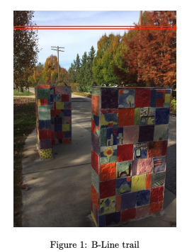

1. We just saw that PCA might be able to replace DCT. But, it seems to depend on the quality of PCA. One way to improve the quality is to increase the size of your data set, so that you can start from a good sample covariance matrix. To do so, go back to the R matrix generation procedure. But, this time, increase the total number of blocks to 90 (30 blocks per channel). Note that each block is with 8 × 768 pixels once again. See if the eigenvectors are better looking (submit the plot).

**Solution**

```python
import cv2
import numpy as np
import pandas as pd
from matplotlib import pyplot as plt
import seaborn as sns
from IPython.display import Image
# from google.colab.patches import cv2_imshow
import random
```

```
(1024, 768, 3)
```

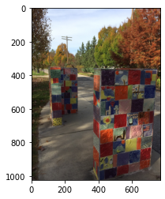

```python
X = cv2.imread('data/IMG_1878.JPG')
X = cv2.cvtColor(X, cv2.COLOR_BGR2RGB)
print(X.shape)
plt.imshow(X)
plt.show()
```

```python
x_len, y_len = X.shape[0], X.shape[1]
x_len, y_len
```

```
(1024, 768)
```

```python
# We Extraxt each of the R, B , G channels
X_r, X_g, X_b = X[:, :, 0], X[:, :, 1], X[:, :, 2]
```

```python
#Samplesize
S = 8
```

```python
initial_row = random.randrange(x_len-S)
X_r_sample_1 = X_r[initial_row: initial_row+S,:]

initial_row = random.randrange(x_len-S)
X_r_sample_2 = X_r[initial_row: initial_row+S,:]

initial_row = random.randrange(x_len-S)
X_r_sample_3 = X_r[initial_row: initial_row+S,:]




initial_row = random.randrange(x_len-S)
X_g_sample_1 = X_g[initial_row: initial_row+S,:]

initial_row = random.randrange(x_len-S)
X_g_sample_2 = X_g[initial_row: initial_row+S,:]

initial_row = random.randrange(x_len-S)
X_g_sample_3 = X_g[initial_row: initial_row+S,:]



initial_row = random.randrange(x_len-S)
X_b_sample_1 = X_b[initial_row: initial_row+S,:]

initial_row = random.randrange(x_len-S)
X_b_sample_2 = X_b[initial_row: initial_row+S,:]

initial_row = random.randrange(x_len-S)
X_b_sample_3 = X_b[initial_row: initial_row+S,:]

R = np.concatenate( [X_r_sample_1,
                     X_r_sample_2,
                     X_r_sample_3,
                     X_g_sample_1,
                     X_g_sample_2,
                     X_g_sample_3,
                     X_b_sample_1,
                     X_b_sample_2,
                     X_b_sample_3], axis=1)
```

```python
R.shape
```

```
(8, 6912)
```

As mentioned in the quesiton, now the shape is (8,6912)

```python
# Now we subtract the mean vector of size 8 × 1 from all 6912 vectors.
R = R - np.mean(R, axis = 1).reshape(-1,1)
```

```python
np.mean(R, axis = 1).reshape(-1,1).shape
```

```
(8, 1)
```

```python
# Next we calculate the covariance matrix, which will be an 8 × 8 matrix.
cov_R = np.dot(R, R.T)*(1/R.shape[1]-1)
# cov_R = np.cov(R)
```

```python
cov_R.shape
```

```
(8, 8)
```

```python
# as we know our cov_R matrix is symmetric, we use eigh over eig,  and also to generate a sorted response
# v is the eigenvalues
# W is normalized eigenvector
v, W = np.linalg.eigh(cov_R)
W_t = W.T
```

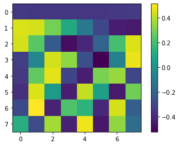

```python
plt.imshow(W_t)
plt.colorbar()

plt.show()
```

In M02-S21 we saw the below Plot

[figure not shown]

**We can see that the plots are not similar, and not of good quality.**

Now we increase to 90 block size

```python
#Samplesize
S = 8
```

```python
initial_row = random.randrange(x_len-S)
X_r_sample_1 = X_r[initial_row: initial_row+S,:]
initial_row = random.randrange(x_len-S)
X_r_sample_2 = X_r[initial_row: initial_row+S,:]
initial_row = random.randrange(x_len-S)
X_r_sample_3 = X_r[initial_row: initial_row+S,:]
initial_row = random.randrange(x_len-S)
X_r_sample_4 = X_r[initial_row: initial_row+S,:]
initial_row = random.randrange(x_len-S)
X_r_sample_5 = X_r[initial_row: initial_row+S,:]
initial_row = random.randrange(x_len-S)
X_r_sample_6 = X_r[initial_row: initial_row+S,:]
initial_row = random.randrange(x_len-S)
X_r_sample_7 = X_r[initial_row: initial_row+S,:]
initial_row = random.randrange(x_len-S)
X_r_sample_8 = X_r[initial_row: initial_row+S,:]
initial_row = random.randrange(x_len-S)
X_r_sample_9 = X_r[initial_row: initial_row+S,:]
initial_row = random.randrange(x_len-S)
X_r_sample_10 = X_r[initial_row: initial_row+S,:]
initial_row = random.randrange(x_len-S)
X_r_sample_11 = X_r[initial_row: initial_row+S,:]
initial_row = random.randrange(x_len-S)
X_r_sample_12 = X_r[initial_row: initial_row+S,:]
initial_row = random.randrange(x_len-S)
X_r_sample_13 = X_r[initial_row: initial_row+S,:]
initial_row = random.randrange(x_len-S)
X_r_sample_14 = X_r[initial_row: initial_row+S,:]
initial_row = random.randrange(x_len-S)
X_r_sample_15 = X_r[initial_row: initial_row+S,:]
initial_row = random.randrange(x_len-S)
X_r_sample_16 = X_r[initial_row: initial_row+S,:]
initial_row = random.randrange(x_len-S)
X_r_sample_17 = X_r[initial_row: initial_row+S,:]
initial_row = random.randrange(x_len-S)
X_r_sample_18 = X_r[initial_row: initial_row+S,:]
initial_row = random.randrange(x_len-S)
X_r_sample_19 = X_r[initial_row: initial_row+S,:]
initial_row = random.randrange(x_len-S)
X_r_sample_20 = X_r[initial_row: initial_row+S,:]
initial_row = random.randrange(x_len-S)
X_r_sample_21 = X_r[initial_row: initial_row+S,:]
initial_row = random.randrange(x_len-S)
X_r_sample_22 = X_r[initial_row: initial_row+S,:]
initial_row = random.randrange(x_len-S)
X_r_sample_23 = X_r[initial_row: initial_row+S,:]
initial_row = random.randrange(x_len-S)
X_r_sample_24 = X_r[initial_row: initial_row+S,:]
initial_row = random.randrange(x_len-S)
X_r_sample_25 = X_r[initial_row: initial_row+S,:]
initial_row = random.randrange(x_len-S)
X_r_sample_26 = X_r[initial_row: initial_row+S,:]
initial_row = random.randrange(x_len-S)
X_r_sample_27 = X_r[initial_row: initial_row+S,:]
initial_row = random.randrange(x_len-S)
X_r_sample_28 = X_r[initial_row: initial_row+S,:]
initial_row = random.randrange(x_len-S)
X_r_sample_29 = X_r[initial_row: initial_row+S,:]
initial_row = random.randrange(x_len-S)
X_r_sample_30 = X_r[initial_row: initial_row+S,:]




initial_row = random.randrange(x_len-S)
X_g_sample_1 = X_g[initial_row: initial_row+S,:]
initial_row = random.randrange(x_len-S)
X_g_sample_2 = X_g[initial_row: initial_row+S,:]
initial_row = random.randrange(x_len-S)
X_g_sample_3 = X_g[initial_row: initial_row+S,:]
initial_row = random.randrange(x_len-S)
X_g_sample_4 = X_g[initial_row: initial_row+S,:]
initial_row = random.randrange(x_len-S)
X_g_sample_5 = X_g[initial_row: initial_row+S,:]
initial_row = random.randrange(x_len-S)
X_g_sample_6 = X_g[initial_row: initial_row+S,:]
initial_row = random.randrange(x_len-S)
X_g_sample_7 = X_g[initial_row: initial_row+S,:]
initial_row = random.randrange(x_len-S)
X_g_sample_8 = X_g[initial_row: initial_row+S,:]
initial_row = random.randrange(x_len-S)
X_g_sample_9 = X_g[initial_row: initial_row+S,:]
initial_row = random.randrange(x_len-S)
X_g_sample_10 = X_g[initial_row: initial_row+S,:]
initial_row = random.randrange(x_len-S)
X_g_sample_11 = X_g[initial_row: initial_row+S,:]
initial_row = random.randrange(x_len-S)
X_g_sample_12 = X_g[initial_row: initial_row+S,:]
initial_row = random.randrange(x_len-S)
X_g_sample_13 = X_g[initial_row: initial_row+S,:]
initial_row = random.randrange(x_len-S)
X_g_sample_14 = X_g[initial_row: initial_row+S,:]
initial_row = random.randrange(x_len-S)
X_g_sample_15 = X_g[initial_row: initial_row+S,:]
initial_row = random.randrange(x_len-S)
X_g_sample_16 = X_g[initial_row: initial_row+S,:]
initial_row = random.randrange(x_len-S)
X_g_sample_17 = X_g[initial_row: initial_row+S,:]
initial_row = random.randrange(x_len-S)
X_g_sample_18 = X_g[initial_row: initial_row+S,:]
initial_row = random.randrange(x_len-S)
X_g_sample_19 = X_g[initial_row: initial_row+S,:]
initial_row = random.randrange(x_len-S)
X_g_sample_20 = X_g[initial_row: initial_row+S,:]
initial_row = random.randrange(x_len-S)
X_g_sample_21 = X_g[initial_row: initial_row+S,:]
initial_row = random.randrange(x_len-S)
X_g_sample_22 = X_g[initial_row: initial_row+S,:]
initial_row = random.randrange(x_len-S)
X_g_sample_23 = X_g[initial_row: initial_row+S,:]
initial_row = random.randrange(x_len-S)
X_g_sample_24 = X_g[initial_row: initial_row+S,:]
initial_row = random.randrange(x_len-S)
X_g_sample_25 = X_g[initial_row: initial_row+S,:]
initial_row = random.randrange(x_len-S)
X_g_sample_26 = X_g[initial_row: initial_row+S,:]
initial_row = random.randrange(x_len-S)
X_g_sample_27 = X_g[initial_row: initial_row+S,:]
initial_row = random.randrange(x_len-S)
X_g_sample_28 = X_g[initial_row: initial_row+S,:]
initial_row = random.randrange(x_len-S)
X_g_sample_29 = X_g[initial_row: initial_row+S,:]
initial_row = random.randrange(x_len-S)
X_g_sample_30 = X_g[initial_row: initial_row+S,:]



initial_row = random.randrange(x_len-S)
X_b_sample_1 = X_b[initial_row: initial_row+S,:]
initial_row = random.randrange(x_len-S)
X_b_sample_2 = X_b[initial_row: initial_row+S,:]
initial_row = random.randrange(x_len-S)
X_b_sample_3 = X_b[initial_row: initial_row+S,:]
initial_row = random.randrange(x_len-S)
X_b_sample_4 = X_b[initial_row: initial_row+S,:]
initial_row = random.randrange(x_len-S)
X_b_sample_5 = X_b[initial_row: initial_row+S,:]
initial_row = random.randrange(x_len-S)
X_b_sample_6 = X_b[initial_row: initial_row+S,:]
initial_row = random.randrange(x_len-S)
X_b_sample_7 = X_b[initial_row: initial_row+S,:]
initial_row = random.randrange(x_len-S)
X_b_sample_8 = X_b[initial_row: initial_row+S,:]
initial_row = random.randrange(x_len-S)
X_b_sample_9 = X_b[initial_row: initial_row+S,:]
initial_row = random.randrange(x_len-S)
X_b_sample_10 = X_b[initial_row: initial_row+S,:]
initial_row = random.randrange(x_len-S)
X_b_sample_11 = X_b[initial_row: initial_row+S,:]
initial_row = random.randrange(x_len-S)
X_b_sample_12 = X_b[initial_row: initial_row+S,:]
initial_row = random.randrange(x_len-S)
X_b_sample_13 = X_b[initial_row: initial_row+S,:]
initial_row = random.randrange(x_len-S)
X_b_sample_14 = X_b[initial_row: initial_row+S,:]
initial_row = random.randrange(x_len-S)
X_b_sample_15 = X_b[initial_row: initial_row+S,:]
initial_row = random.randrange(x_len-S)
X_b_sample_16 = X_b[initial_row: initial_row+S,:]
initial_row = random.randrange(x_len-S)
X_b_sample_17 = X_b[initial_row: initial_row+S,:]
initial_row = random.randrange(x_len-S)
X_b_sample_18 = X_b[initial_row: initial_row+S,:]
initial_row = random.randrange(x_len-S)
X_b_sample_19 = X_b[initial_row: initial_row+S,:]
initial_row = random.randrange(x_len-S)
X_b_sample_20 = X_b[initial_row: initial_row+S,:]
initial_row = random.randrange(x_len-S)
X_b_sample_21 = X_b[initial_row: initial_row+S,:]
initial_row = random.randrange(x_len-S)
X_b_sample_22 = X_b[initial_row: initial_row+S,:]
initial_row = random.randrange(x_len-S)
X_b_sample_23 = X_b[initial_row: initial_row+S,:]
initial_row = random.randrange(x_len-S)
X_b_sample_24 = X_b[initial_row: initial_row+S,:]
initial_row = random.randrange(x_len-S)
X_b_sample_25 = X_b[initial_row: initial_row+S,:]
initial_row = random.randrange(x_len-S)
X_b_sample_26 = X_b[initial_row: initial_row+S,:]
initial_row = random.randrange(x_len-S)
X_b_sample_27 = X_b[initial_row: initial_row+S,:]
initial_row = random.randrange(x_len-S)
X_b_sample_28 = X_b[initial_row: initial_row+S,:]
initial_row = random.randrange(x_len-S)
X_b_sample_29 = X_b[initial_row: initial_row+S,:]
initial_row = random.randrange(x_len-S)
X_b_sample_30 = X_b[initial_row: initial_row+S,:]


R_90 = np.concatenate( [X_r_sample_1, X_r_sample_2,  X_r_sample_3,  X_r_sample_4, X_r_sample_5,
                        X_r_sample_6,  X_r_sample_7, X_r_sample_8, X_r_sample_9, X_r_sample_10,
                        X_r_sample_11, X_r_sample_12,  X_r_sample_13,  X_r_sample_14, X_r_sample_15,
                        X_r_sample_16,  X_r_sample_17, X_r_sample_18, X_r_sample_19, X_r_sample_20,
                        X_r_sample_21, X_r_sample_22,  X_r_sample_23,  X_r_sample_24, X_r_sample_25,
                        X_r_sample_26,  X_r_sample_27, X_r_sample_28, X_r_sample_29, X_r_sample_30,

                        X_g_sample_1, X_g_sample_2, X_g_sample_3,  X_g_sample_4, X_g_sample_5,
                        X_g_sample_6, X_g_sample_7,  X_g_sample_8, X_g_sample_9, X_g_sample_10,
                        X_g_sample_11, X_g_sample_12, X_g_sample_13,  X_g_sample_14, X_g_sample_15,
                        X_g_sample_16, X_g_sample_17,  X_g_sample_18, X_g_sample_19, X_g_sample_20,
                        X_g_sample_21, X_g_sample_22, X_g_sample_23,  X_g_sample_24, X_g_sample_25,
                        X_g_sample_26, X_g_sample_27,  X_g_sample_28, X_g_sample_29, X_g_sample_30,


                        X_b_sample_1, X_b_sample_2, X_b_sample_3, X_b_sample_4, X_b_sample_5,
                        X_b_sample_6, X_b_sample_7, X_b_sample_8, X_b_sample_9, X_b_sample_10,
                        X_b_sample_11, X_b_sample_12, X_b_sample_13, X_b_sample_14, X_b_sample_15,
                        X_b_sample_16, X_b_sample_17, X_b_sample_18, X_b_sample_19, X_b_sample_20,
                        X_b_sample_21, X_b_sample_22, X_b_sample_23, X_b_sample_24, X_b_sample_25,
                        X_b_sample_26, X_b_sample_27, X_b_sample_28, X_b_sample_29, X_b_sample_30], axis=1)
```

```python
R_90.shape
```

```
(8, 69120)
```

```python
# Now we subtract the mean vector of size 8 × 1 from all 6912 vectors.
R_90 = R_90 - np.mean(R_90, axis = 1).reshape(-1,1)
```

```python
# Next we calculate the covariance matrix, which will be an 8 × 8 matrix.
cov_R_90 = np.dot(R_90, R_90.T)*(1/R_90.shape[1]-1)
#cov_R_90 = np.cov(R_90)
```

```python
# as we know our cov_R matrix is symmetric, we use eigh over eig,  and also to generate a sorted response
# v is the eigenvalues
# W is normalized eigenvector
v_90, W_90 = np.linalg.eigh(cov_R_90)
W_90_t = W_90.T
```

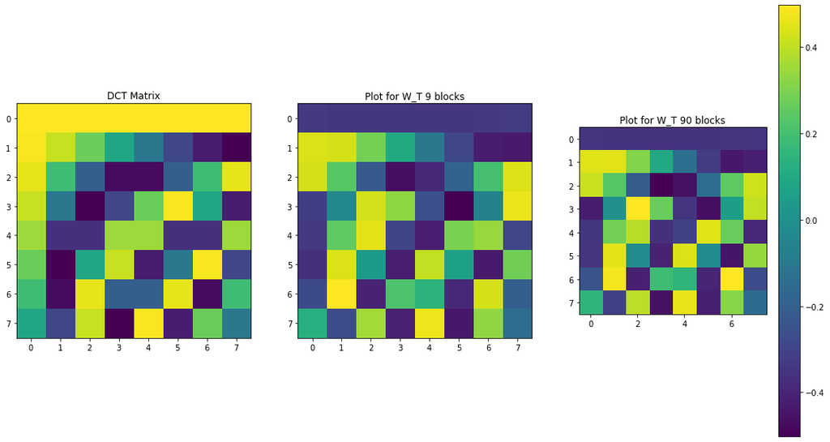

```python
plt.figure(figsize=[18,10]);

plt.subplot(1, 3, 1)
from scipy.fftpack import dct
dct_mat = dct(np.eye(8), axis=0)
plt.imshow(dct_mat)
plt.title('DCT Matrix')

plt.subplot(1, 3, 2)
plt.imshow(W_t)
plt.title('Plot for W_T 9 blocks')

plt.subplot(1, 3, 3)
plt.imshow(W_90_t)
plt.title('Plot for W_T 90 blocks')

plt.colorbar()

plt.show()
```

Commenting on the above charts

The first row looks flipped, and DCT of value 1 is coming to value of -1 for mine.

W_9 blocks vs w_90 blocks looks similar plot but there is a very small change . There is very slight improvement

I reckon if we increse the number of blocks further to may be 900 or so, we would see that it us getting better and more closer to the DCT matrix plot.

our w_90 blocks plot looks more similar towards the DCT matrix plot

## P2: Instantaneous Source Separation [6 points]

1. From x_ica_1.wav to x_ica_4.wav are four recordings we observed at an audio scene. In this audio scene, there are three speakers saying something at the same time plus a motorcycle passing by. You may want to listen to those recordings to check out who says what, but I made it very careful so that you guys cannot understand what they are saying. In other words, I multiplied a 4 × 4 mixing matrix $A$ to the four sources to create the four channel mixture:

$$ \begin{equation} \begin{bmatrix} x_1(t) \\ x_2(t) \\ x_3(t) \\ x_4(t) \end{bmatrix} = A \begin{bmatrix} s_1(t) \\ s_2(t) \\ s_3(t) \\ s_4(t) \end{bmatrix} \tag{1} \end{equation}$$

1. But, as you’ve learned how to do source separation using ICA, you should be able to separate them out into four sources: three clean speech signals and the motorcycle noise. Listen to your separated sources and transcribe what they are saying. Submit your separated .wav files along with your transcription.
2. At every iteration of the ICA algorithm, use these as your update rules: $$ \begin{equation} ΔW ← (NI - g(Y)f(Y)')W \tag{2}\end{equation}$$

$$ \begin{equation} ΔW ← W + 𝜌ΔW \tag{3}\end{equation}$$$$ \begin{equation} Y ← WZ \tag{4}\end{equation}$$

Where $$ \begin{equation} W :The~ICA~unmixing~matrix~you're~estimating \tag{5}\end{equation}$$

$$ \begin{equation} Y :The~4 𝖷 N~source~matrix~you're~estimating \tag{6}\end{equation}$$$$ \begin{equation} Z :Whitened~version~of~your~input~(using~pca) \tag{7}\end{equation}$$$$ \begin{equation} g(x) :tanh(x),(works~element-wise) \tag{8}\end{equation}$$$$ \begin{equation} f(x) :x^3,(works~element-wise) \tag{9}\end{equation}$$$$ \begin{equation} 𝜌 :learning~rate \tag{10}\end{equation}$$$$ \begin{equation} N : number~of~samples \tag{11}\end{equation}$$

1. Don’t forget to whiten your data before applying $ICA!$
1. Implementation notes: Depending on the choice of the learning rate the convergence of the ICA algorithm varies. But I always see the convergence in from 5 sec to 90 sec in my desktop computer

**Solution**

```python
import numpy as np
import pandas as pd
import matplotlib.pyplot as plt
import librosa as lb
import scipy.stats as stats
from numpy import linalg
import IPython.display as ipd
```

```python
x_ica_1, sr_1 = lb.load("data/x_ica_1.wav", sr=None)
print('SampleRate of x_ica_1.wav is {}'.format(sr_1))
print('Original Audio x_ica_1.wav sounds as ')
ipd.Audio(x_ica_1, rate = sr_1)
```

```
SampleRate of x_ica_1.wav is 16000
Original Audio x_ica_1.wav sounds as
```

[interactive chart not shown]

```python
x_ica_2, sr_2 = lb.load("data/x_ica_2.wav", sr=None)
print('SampleRate of x_ica_2.wav is {}'.format(sr_2))
print('Original Audio x_ica_2.wav sounds as ')
ipd.Audio(x_ica_2, rate = sr_2)
```

```
SampleRate of x_ica_2.wav is 16000
Original Audio x_ica_2.wav sounds as
```

[interactive chart not shown]

```python
x_ica_3, sr_3 = lb.load("data/x_ica_3.wav", sr=None)
print('SampleRate of x_ica_3.wav is {}'.format(sr_3))
print('Original Audio x_ica_3.wav sounds as ')
ipd.Audio(x_ica_3, rate = sr_3)
```

```
SampleRate of x_ica_3.wav is 16000
Original Audio x_ica_3.wav sounds as
```

[interactive chart not shown]

```python
x_ica_4, sr_4 = lb.load("data/x_ica_4.wav", sr=None)
print('SampleRate of x_ica_4.wav is {}'.format(sr_4))
print('Original Audio x_ica_4.wav sounds as ')
ipd.Audio(x_ica_4, rate = sr_4)
```

```
SampleRate of x_ica_4.wav is 16000
Original Audio x_ica_4.wav sounds as
```

[interactive chart not shown]

```python
X = np.array([x_ica_1, x_ica_2, x_ica_3, x_ica_4])
print("Shape of X which is our input sounds in a single array is {}".format(X.shape))
```

```
Shape of X which is our input sounds in a single array is (4, 42292)
```

```python
# Now we subtract the mean vector
X = X - np.mean(X, axis = 1).reshape(-1,1)


# Next we calculate the covariance matrix, which will be an 4×4 matrix.
cov_X = np.dot(X, X.T)*(1/X.shape[1]-1)
```

```python
cov_X.shape
```

```
(4, 4)
```

```python
# u is eigen_vector
# s is eigen_value
u, s, vh = np.linalg.svd(cov_X)

u_t = u.T
```

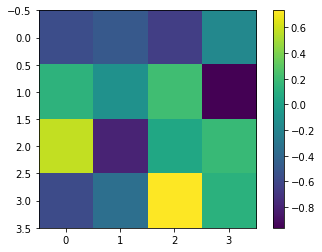

```python
plt.imshow(u_t)
plt.colorbar()
plt.show()
```

After doing PCA we need to whiten our data.

The projection for whitening is

$ Λ^{-1/2} W^T X $

```python
clean_Z = np.dot( np.dot( np.multiply( u, (1/np.sqrt(s)))  , u_t.T ) , X)
```

```python
clean_Z.shape
```

```
(4, 42292)
```

```python
clean_Z
```

```
array([[ 0.46296525,  0.70828366,  0.53909963, ..., -1.2492223 ,
        -1.3572595 , -1.396491  ],
       [ 0.35064358,  0.53580385,  0.407626  , ..., -0.9449533 ,
        -1.026211  , -1.056286  ],
       [-0.6502932 , -0.99442357, -0.756757  , ...,  1.753854  ,
         1.9052094 ,  1.9605677 ],
       [-0.07365038, -0.11254054, -0.08560529, ...,  0.19847782,
         0.2155334 ,  0.22186048]], dtype=float32)
```

After having cleaned Z we perform ICA on the given algorithm

With multiple hit and tries we settled down with roh as 0.000001, and number of iteration as 5000. We could have also done an early stop algorithm to stop earlier when the del reaches a threshold . This all being our hyperparameters we implement the below

```python
W = np.identity(4)
Y = np.dot(W,clean_Z)
del_W = np.identity(4)
N = clean_Z.shape[1]
rho = 0.000001
for i in range(5000):
    del_W  = np.dot( (np.multiply(N, np.identity(4)) - (np.dot( np.tanh(Y),np.power(Y,3).T  ))) , W)
    W = W + np.multiply(rho, del_W)
    Y = np.dot(W,clean_Z)
```

```python
ipd.Audio(Y[0], rate = sr_1)
```

[interactive chart not shown]

we can undersrand the speaker is saying "22 or 23"

```python
ipd.Audio(Y[1], rate = sr_2)
```

[interactive chart not shown]

we can undersrand the speaker is saying "I ate every oyesters on nora's plate"

```python
ipd.Audio(Y[2], rate = sr_3)
```

[interactive chart not shown]

we can undersrand this is the sound of the motercycle

```python
ipd.Audio(Y[3], rate = sr_4)
```

[interactive chart not shown]

we can undersrand the speaker is saying "it's not easy to create iluminating examples"

So we have separated the audio using ICA and can be heard above.

## P3: Ideal Masks [4 points]

1. piano.wav and ocean.wav are two sources you’re interested in. Load them separately and apply STFT with 1024 point frames and 50% overlap. Use Hann windows. Let’s call these two spectrograms $S$ and $N$, respectively. Discard the complex conjugate part, so eventually they will be an 513 × 158 matrix1 . Later on in this problem when you recover the time domain signal out of this, you can easily recover the discarded half from the existing half so that you can do inverse-DFT on the column vector of full 1024 points. Hint: Why 513, not 512? Create a very short random signal with 16 samples, and do a DFT transform to convert it into a spectrum of 16 complex values. Check out their complex coefficients to see why you need N/2 + 1, not N/2. I will allow you to use other implementations, such as librosa.stft, but I strongly encourage you to reuse your code from Homework 2
1. Now you build a mixture spectrogram by simply adding the two source spectrograms: $X = S + N$. Note that all the numbers here are complex values.
1. Since you know the sources, the source separation job is trivial. One way is to calculate the ideal masks $M = \frac{S}{S+N}$ (once again, note that they are all complex valued and the division is element-wise). By the definition of the mixture spectrogram, $S = M ⊙ X$, where $⊙$ stands for a Hadamard product. But we won’t use this one today.
2. Sometimes we can only estimate a nonnegative real-valued masking matrix $ \bar{M}$ especially if we don’t have an access to the phase of the sources. For example, $ \bar{M}= \frac{|S|^2}{|S|^2+|N|^2}$ . Go ahead and calculate $ \bar{M}$ from your sources, and multiply it to your mixture spectrogram, i.e. $S ≈ M ⊙ X$. Convert your estimated piano spectrogram back to the time domain. Submit the .wav file of your recovered piano source.
3. Listen to the recovered source. Is it too different from the original? One way to objectively measure the quality of the recovered signal is to compare it to the original signal by using a metric called Signal-to-Noise Ratio (SNR):

$$ \begin{equation} SNR = 10log_{10} ( \frac{∑_t\{s(t)\}^2}{∑_t\{s(t) - \hat s(t)\}^2 } ) \tag{12}\end{equation}$$

where $s(t)$ is the t-th sample of the original source and $ ŝ(t) $ is that of the recovered one. Evaluate the SNR between piano.wav and your reconstruction for it. Note: their lengths could be slightly different. Just ignore the small difference in the end.

1. Yet another masking scheme is something called Ideal Binary Masks (IBM) . This time, we use a binary (0 or 1) masking matrix B, which is definded by

$$ \begin{equation} B_{ft}= \begin{cases} 1 &{if~|S|_{ft}>|N|_{ft} } \\\\ 0 &\text{otherwise} \end{cases} \tag{13}\end{equation}$$

1. Create your IBM from the sources, and apply it to your mixture spectrogram, $S ≈ B ⊙ X$. Do the inverse STFT. How does it sound? What’s its SNR value?
1. Don’t forget to create audio players for the sound examples in your iPython (i.e., jupyter or Google Colab) notebook. Check if they play sound in the .html version.

**Solution**

```python
import numpy as np
import pandas as pd
import matplotlib.pyplot as plt
import librosa as lb
import scipy.stats as stats
from numpy import linalg
import IPython.display as ipd
```

```python
x_piano, sr_piano = lb.load("data/piano.wav", sr=None)
print('SampleRate of x_piano is {}'.format(sr_piano))
print('Original Audio piano.wav provided by professor sounds as ')
print('This is our Signal')
print('Length of the stream is {}'.format(len(x_piano)))
ipd.Audio(x_piano, rate = sr_piano)
```

```
SampleRate of x_piano is 16000
Original Audio piano.wav provided by professor sounds as
This is our Signal
Length of the stream is 80000
```

[interactive chart not shown]

```python
x_ocean, sr_ocean = lb.load("data/ocean.wav", sr=None)
print('SampleRate of x_ocean is {}'.format(sr_ocean))
print('Original Audio ocean.wav provided by professor sounds as ')
print('This is our Noise')
print('Length of the stream is {}'.format(len(x_ocean)))
ipd.Audio(x_ocean, rate = sr_ocean)
```

```
SampleRate of x_ocean is 16000
Original Audio ocean.wav provided by professor sounds as
This is our Noise
Length of the stream is 80000
```

[interactive chart not shown]

```python
point_frame = 1024
```

```python
S = lb.stft(x_piano, n_fft=point_frame,window='hann', hop_length=point_frame//2,center=True)
N = lb.stft(x_ocean, n_fft=point_frame,window='hann', hop_length=point_frame//2,center=True)
```

```python
print('Shape of S is {}'.format(S.shape))
print('Shape of N is {}'.format(N.shape))
```

```
Shape of S is (513, 157)
Shape of N is (513, 157)
```

```python
print('Shape of S is {}'.format(S.shape))
print('Shape of N is {}'.format(N.shape))
```

```
Shape of S is (513, 157)
Shape of N is (513, 157)
```

I used the library librosa for sftp as allowed by professor

So now we see after making a 50% overlap and using Hann window, we get a shape of 513, and not 512.

```python
print(S[100][100])
print(N[100][100])
```

```
(1.2777823+0.25647366j)
(1.0696245+0.90124947j)
```

```python
S_abs = np.abs(S)
N_abs = np.abs(N)
```

```python
print(S_abs[100][100])
print(N_abs[100][100])
print('Shape of S is {}'.format(S.shape))
print('Shape of N is {}'.format(N.shape))
```

```
1.3032676
1.3986949
Shape of S is (513, 157)
Shape of N is (513, 157)
```

```
spectrogram of S is
```

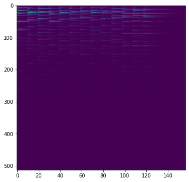

```python
print('spectrogram of S is')
plt.figure(figsize=(6,6))
plt.imshow(S_abs,aspect="auto")
plt.show()
```

```
spectrogram of N is
```

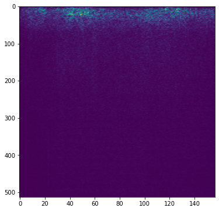

```python
print('spectrogram of N is')
plt.figure(figsize=(6,6))
plt.imshow(N_abs,aspect="auto")
plt.show()
```

So now we need to eliminate the complex part

Contrasting with the above, we see that now we have eliminated the complex part of S and N

```python
X = S+N
```

```python
print(X[100][100])
print('Shape of X is {}'.format(X.shape))
```

```
(2.3474069+1.1577232j)
Shape of X is (513, 157)
```

```python
X_abs = np.abs(X)
```

```python
print(X_abs[100][100])
print('Shape of X is {}'.format(X_abs.shape))
```

```
2.617373
Shape of X is (513, 157)
```

```
spectrogram of X_abs is
```

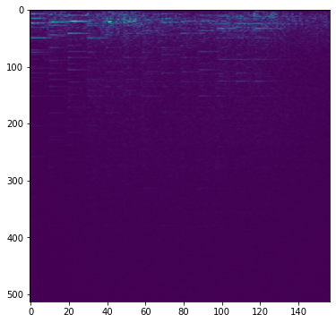

```python
print('spectrogram of X_abs is')
plt.figure(figsize=(6,6))
plt.imshow(X_abs,aspect="auto")
plt.show()
```

```python
print('The X which is the Piano + the Ocean sound sounds like below before our Source seperation operation')
x_inv_stft = lb.istft(X_abs)
ipd.Audio(x_inv_stft, rate = sr_piano/2)
```

```
The X which is the Piano + the Ocean sound sounds like below before our Source seperation operation
```

[interactive chart not shown]

We now compute $ \bar{M}= \frac{|S|^2}{|S|^2+|N|^2}$ as below

```python
M_bar = S_abs**2 / ((S_abs**2) + (N_abs**2))
```

```python
M_bar.shape
```

```
(513, 157)
```

Next, doing the operation $S ≈ M ⊙ X$

```python
S_recovered = np.multiply(M_bar, X)
# S_recovered = np.multiply(M_bar, (S.real+N.real))
```

```python
print('The S_recovered which is the Piano recovered sound, sounds like below after our Source seperation operation')
piano_recovered = lb.istft(S_recovered, hop_length=point_frame//2, center=True)
# piano_recovered = lb.istft(S_recovered)
ipd.Audio(piano_recovered, rate = sr_piano)
```

```
The S_recovered which is the Piano recovered sound, sounds like below after our Source seperation operation
```

[interactive chart not shown]

```
spectrogram of S_recovered is
```

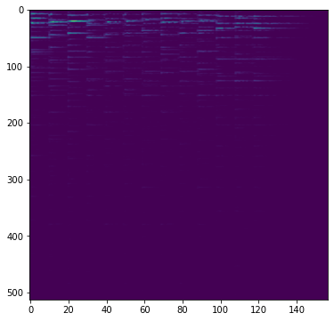

```python
print('spectrogram of S_recovered is')
plt.figure(figsize=(6,6))
plt.imshow(np.abs(S_recovered),aspect="auto")
plt.show()
```

This recovered sound is similar to our piano, but it sounds a bit suppressed and damp

Next we need to compute SNR as

$$ \begin{equation} SNR = 10log_{10} ( \frac{∑_t\{s(t)\}^2}{∑_t\{s(t) - \hat s(t)\}^2 } ) \tag{12}\end{equation}$$

```python
def SNR(s, s_hat):
    min_shape = min(s.shape[0],s_hat.shape[0])
    s=s[:min_shape]
    s_hat = s_hat[:min_shape]
    return np.abs(10*(np.log10( np.sum(np.square(s)) / (np.sum(np.square(s-s_hat))) )))
```

```python
snr_m_bar = SNR(x_piano, piano_recovered)
print('The SNR value for the recovered source is: {}'.format(snr_m_bar))
```

```
The SNR value for the recovered source is: 8.116028308868408
```

Next We try to implement $B_{ft}$ with the below formula

$$ \begin{equation} B_{ft}= \begin{cases} 1 &{if~|S|_{ft}>|N|_{ft} } \\\\ 0 &\text{otherwise} \end{cases} \tag{13}\end{equation}$$

```python
B = np.zeros((S.shape[0], S.shape[1]))
for row in range(B.shape[0]):
    for col in range(B.shape[1]):
        if S_abs[row,col] > N_abs[row,col]:
            B[row,col]=1
```

Now we try to recreate our source as $S ≈ B ⊙ X$

```python
S_recovered_ibm = np.multiply(B, X)
```

```python
print('The S_recovered_ibm which is the Piano recovered sound with IBM, sounds like below after our Source seperation operation')
piano_recovered_ibm = lb.istft(S_recovered_ibm, hop_length=point_frame//2, center=True)
# piano_recovered_ibm = lb.istft(S_recovered_ibm)
ipd.Audio(piano_recovered_ibm, rate = sr_piano)
```

```
The S_recovered_ibm which is the Piano recovered sound with IBM, sounds like below after our Source seperation operation
```

[interactive chart not shown]

```
spectrogram of S_recovered_ibm is
```

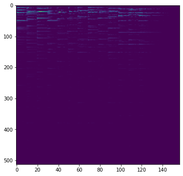

```python
print('spectrogram of S_recovered_ibm is')
plt.figure(figsize=(6,6))
plt.imshow(np.abs(S_recovered_ibm),aspect="auto")
plt.show()
```

This recovered sound is similar to our piano, it also sounds a lot muzzled over the previous audio of m_bar mixture spectrogram technique

```python
snr_m_bar = SNR(x_piano, piano_recovered_ibm)
print('The SNR value for the recovered source with the IBM technique is: {}'.format(snr_m_bar))
```

```
The SNR value for the recovered source with the IBM technique is: 7.374315235818338
```

Here we see that the SNR for the IBM is now almost close but a little bit lower than than of the M-bar rechnique of earlier.

As per me, I prefer the M-bar results over the IBM approach. and it is also evident from the SNR results of both, in case of IBM we are getting lower SNR value with respect to the M-bar SNR value. Higher the SNR value, better is the outpot